# Video Games Exploratory Data Analysis

Created by: David Hay and Kimberly McNeil (Fall 2024)

Our Chosen Dataset: Video Game Sales

Dataset Link: https://www.kaggle.com/datasets/gregorut/videogamesales

## Business Understanding

Its **Purpose**: The purpose of the “Video Game Sales” dataset is to store data regarding video games (name, platform, year, genre, publisher) and how well they sold around the world (North America, Europe, Japan, “Other,” and added all together for a total Global sales).

**Collection Methods**: The dataset (from Kaggle) contains a list of video games with sales greater than 100,000 copies, and it was generated by a scrape of vgchartz.com, which gathers data about these games from the companies and developers producing them. VGChartz sources its data directly from video game companies and their sales in exchange for data on trending sales and other video game metrics.

Why is it **interesting to Others** and the **Prediction Task**: Many people like video games. Knowing certain statistics about video game sales may not only be interesting to gamers but also to video game companies. Companies and Indie Developers can use these statistics to predict what types of games are most popular amongst consumers around the world and learn from the highest ranked.

**Performance Requirements of a Predictive Model** to be Considered Useful: To be considered useful, a predictive model needs to give the correct information based on the input data that we give it. Additionally, if the data that is training the model isn’t consistent and accurate, then the predictions we make will be off, giving us useless information.

## Data Understanding

```python
# Imports
import numpy as np
import pandas as pd
import matplotlib.pyplot as plt
import seaborn as sb
```

```python
import warnings
warnings.filterwarnings('ignore')
```

```python
from google.colab import drive
drive.mount('/content/drive')
```

```python
# Load in dataset
df = pd.read_csv('/content/drive/Shareddrives/Machine Learning Project 01/vgsales.csv').dropna()
#df.loc[[88]]
df.head()
```

|  | Rank | Name | Platform | Year | Genre | Publisher | NA_Sales | EU_Sales | JP_Sales | Other_Sales | Global_Sales |
| --- | --- | --- | --- | --- | --- | --- | --- | --- | --- | --- | --- |
| 0 | 1 | Wii Sports | Wii | 2006.0 | Sports | Nintendo | 41.49 | 29.02 | 3.77 | 8.46 | 82.74 |
| 1 | 2 | Super Mario Bros. | NES | 1985.0 | Platform | Nintendo | 29.08 | 3.58 | 6.81 | 0.77 | 40.24 |
| 2 | 3 | Mario Kart Wii | Wii | 2008.0 | Racing | Nintendo | 15.85 | 12.88 | 3.79 | 3.31 | 35.82 |
| 3 | 4 | Wii Sports Resort | Wii | 2009.0 | Sports | Nintendo | 15.75 | 11.01 | 3.28 | 2.96 | 33.00 |
| 4 | 5 | Pokemon Red/Pokemon Blue | GB | 1996.0 | Role-Playing | Nintendo | 11.27 | 8.89 | 10.22 | 1.00 | 31.37 |

### Data Types for Each Attribute

- Rank (Ranking of overall sales) - Categorical (Ordered)
- Name (The games name) - Categorial (Nominal)
- Platform (Platform of the games release (i.e. PC,PS4, etc.)) - Categorical (Nominal)
- Year (Year of the game's release) - Categorical (Ordered)
- Genre (Genre of the game) - Categorical (Nominal)
- Publisher (Publisher of the game) - Categorical (Nominal)
- NA_Sales (Sales in North America (in millions)) - Quantitative (discrete)
- EU_Sales (Sales in Europe (in millions)) - Quantitative (discrete)
- JP_Sales (Sales in Japan (in millions)) - Quantitative (discrete)
- Other_Sales (ales in the rest of the world (in millions)) - Quantitative (discrete)
- Global_Sales (Total worldwide sales) - Quantitative (discrete)

### Discussing Relevant Attributes

Every attribute listed can be useful for a variety of analyses, aside from perhaps Rank, since we could list the games by global sales and have the same result as listing by rank, with more specific data.

NA_Sales, EU_Sales, JP_Sales, and Other_Sales can be relevant if we wish to break down the larger Global_Sales into different parts, such as if we wish to analyze how a game made in Japan sold more or less copies to Japanese customers compared to those in the United States.

Platform, Year, Genre, and Publisher all relatively serve the same purpose when it comes to how we can use them, and that is to analyze the differences in sales for each category. For example, was the average global sales by Nintendo higher than EA? How were sales in the United States affected by events such as the 2008 Stock Market Crash?

Lastly, the Name attribute would be helpful in either identifying the games or if we wished to see the sales associated with a series, such as games with “Mario” or “Kirby” in the title.

### Assessing data quality

There are a number of games with N/A as the producer or year with 10 or so games having an N/A as both their year and producer. This is obviously not ideal and is probably due to a lack of contact with certain retailers that haven’t agreed to explicit deals with them, or a problem importing certain data that has not been properly cleansed. While fairly labor intensive, the best way to get this data, without a doubt, would be to manually search each game to figure out the producer and year of the game. Some of the data is even within the name of the game, such as *FIFA 2004* having no year data, which speeds up the process and most of the years/producers are easily accessible online. A final justification for this method is that there isn’t too much N/A data, with only about 1.85% of data or 308 cases with each case warranting a quick search at most to fix.

A minor issue we noted as well was that there were a few formatting errors with some producers in their respective strings, but they are still uniquely identifiable making it a quality-of-life change rather than a data-affecting change.

While analyzing the data, we have also discovered a piece of data that was incorrectly inputted into the dataframe, but that will be shown and discussed in the Data Visualization when we look into release years.

## Data Visualization

### Basic Features

#### Global Sales explained by Genre

One of the basic features we can visualize is how a game's genre can affect its sales globally. Since Genre is the categorical explanatory attribute, we can use a bar chart and pie chart to visualize the distribution.

The Bar Chart displays how many sales worldwide every game a specific genre has, while the Pie Chart displays the proportion of total sales each genre has.

```
[1722.84  234.59  444.05  789.87  829.13  242.21  726.76  923.83 1026.2
  389.98 1309.24  173.27]
```

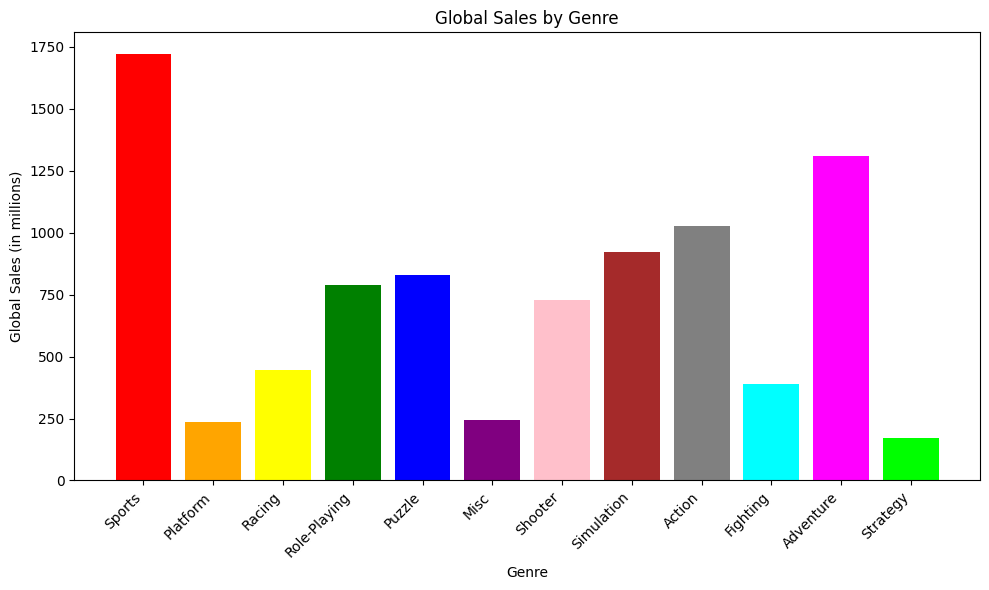

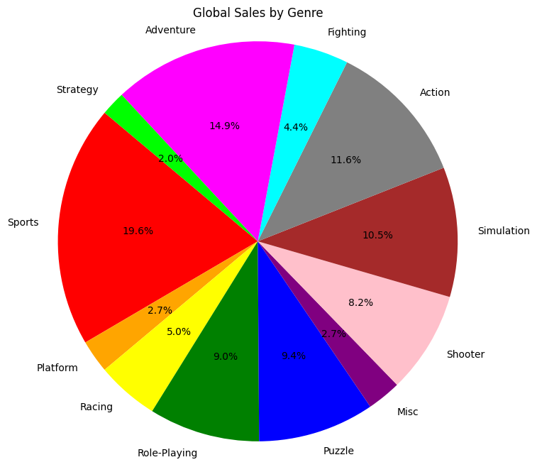

```python
# Get the unique values of Genre and Global_Sales from the DF
X = df["Genre"].unique()
y = df[["Global_Sales"]]

colors = ['red', 'orange', 'yellow', 'green', 'blue', 'purple',
          'pink', 'brown', 'gray', 'cyan', 'magenta', 'lime']
tsales = y.groupby(df["Genre"]).sum().values.ravel()

# Create a bar graph w/ Genre and Global Sales
plt.figure(figsize=(10,6))
plt.bar(X, tsales, color = colors)
plt.xlabel('Genre')
plt.ylabel('Global Sales (in millions)')
plt.title('Global Sales by Genre')
plt.xticks(rotation=45, ha='right')

# Display the plot
plt.tight_layout()
plt.show()

# Create a pie chart w/ the same data
plt.figure(figsize=(8,8))
plt.pie(tsales, labels=X, colors=colors, autopct='%1.1f%%', startangle=140)
plt.title('Global Sales by Genre')
plt.axis('equal')  # Equal aspect ratio ensures that pie is drawn as a circle.
plt.show()
```

#### Global Sales explained by Release Year

Another basic feature we can visualize is how a game's release year can affect its sales globally. Since Year is the categorical explanatory attribute, we can once again use a bar chart and pie chart to visualize the distribution.

The Bar Chart displays how many sales worldwide every game that was released in a specific year has, while the Pie Chart displays the proportion of total sales each year. As we can see below, a pie chart isn't the greatest compared to a bar chart because of the spacing, which makes it more difficult to read, but it is still useful if we wish to see the proportions.

Looking at the distribution of years, we can see an error in the original data frame, since there shouldn't be any recorded games for 2020. This game is Imagine: Makeup Artist for the DS, and it was originally released in 2009.

```
[1.1380e+01 3.5770e+01 2.8860e+01 1.6790e+01 5.0360e+01 5.3940e+01
 3.7070e+01 2.1740e+01 4.7220e+01 7.3450e+01 4.9390e+01 3.2230e+01
 7.6160e+01 4.5980e+01 7.9170e+01 8.8110e+01 1.9915e+02 2.0098e+02
 2.5647e+02 2.5127e+02 2.0156e+02 3.3147e+02 3.9552e+02 3.5785e+02
 4.1401e+02 4.5851e+02 5.2104e+02 6.0992e+02 6.7890e+02 6.6730e+02
 6.0029e+02 5.1580e+02 3.6349e+02 3.6811e+02 3.3703e+02 2.6444e+02
 7.0900e+01 5.0000e-02 2.9000e-01]
```

[figure not shown]

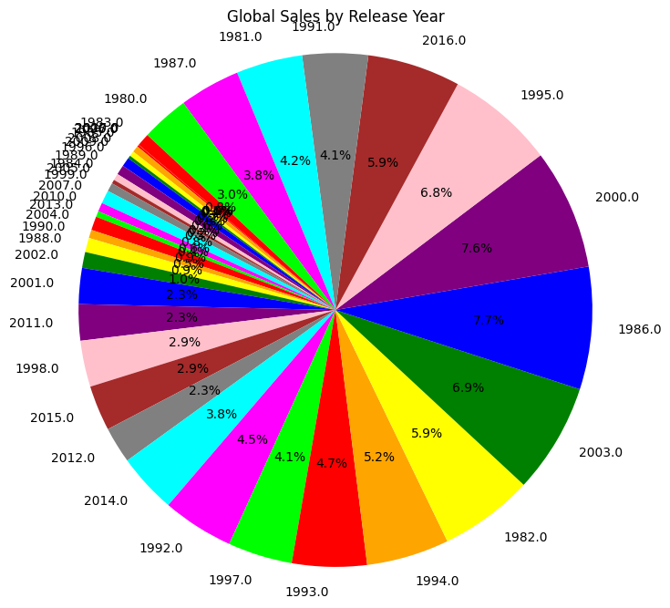

[output not shown]

```python
# Get each year and sales per year
X = df["Year"].unique()
y = df[["Global_Sales"]]

colors = ['red', 'orange', 'yellow', 'green', 'blue', 'purple',
          'pink', 'brown', 'gray', 'cyan', 'magenta', 'lime']
years = y.groupby(df["Year"]).sum().values.ravel()

# Create a bar graph w/ global sales and years
plt.figure(figsize=(10,6))
plt.bar(X, years, color = colors)
plt.xlabel('Year')
plt.ylabel('Total Global Sales (in millions)')
plt.title('Global Sales by Release Year')
plt.xticks(rotation=45, ha='right')

# Display the plot
plt.tight_layout()
plt.show()

# Pie chart w/ the same data
plt.figure(figsize=(8,8))
plt.pie(years, labels=X, colors=colors, autopct='%1.1f%%', startangle=140)
plt.title('Global Sales by Release Year')
plt.axis('equal')  # Equal aspect ratio ensures that pie is drawn as a circle.

plt.show()
```

#### Global Sales by Itself

We can also visualize just the global sales by itself with a histogram and box (and whisker) plot. Unfortunately, the vast majority of the data is very close together and the outliers spread very far out. This means that if we were to graph a histogram or boxplot including these outliers, we wouldn't be able to see most of the distribution. One way of taking care of these outliers is to only work with the data that is within three standard deviations of the mean.

The outliers displayed in the boxplot without the original data frame's outliers are simply the new data frame's outliers, with a new mean and standard deviation relative to the filtered data. Below that boxplot is what the boxplot would look like if we kept the original outliers. As we can see, it's very difficult to read, and it would have been the same for the histogram if we left the outliers.

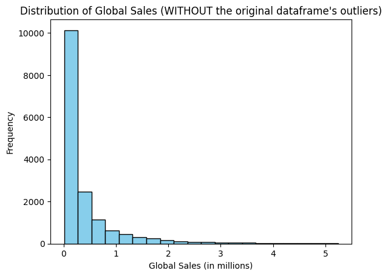

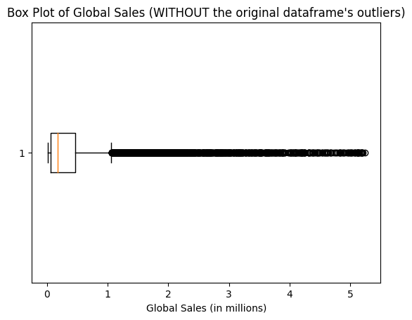

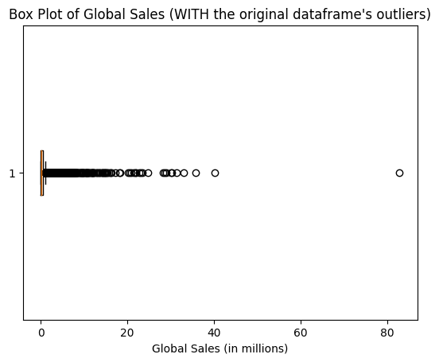

```python
# Filtering the data to not include outliers, as that just leads to only being able to see ~one bar
#This makes a dataframe of all global sales that are within 3 standard deviations of the mean
data_no_outliers = df[np.abs(df.Global_Sales-df.Global_Sales.mean()) <= (3*df.Global_Sales.std())]

# Histogram WITHOUT Outliers
plt.hist(data_no_outliers['Global_Sales'], bins = 20, color='skyblue', edgecolor='black')
plt.xlabel('Global Sales (in millions)')
plt.ylabel('Frequency')
plt.title('Distribution of Global Sales (WITHOUT the original dataframe\'s outliers)')
plt.show()

# Boxplot WITHOUT Outliers
plt.boxplot(data_no_outliers['Global_Sales'], vert=False)
plt.xlabel('Global Sales (in millions)')
plt.title('Box Plot of Global Sales (WITHOUT the original dataframe\'s outliers)')
plt.show()

# Boxplot WITH Outliers (to show how ridiculous it is)
plt.boxplot(df['Global_Sales'], vert=False)
plt.xlabel('Global Sales (in millions)')
plt.title('Box Plot of Global Sales (WITH the original dataframe\'s outliers)')
plt.show()
```

### Insightful Questions and Analysis

#### Question 1

Nintendo is based in Kyoto, Japan, while Electronic Arts (EA) is based in California, USA. Which producer has the highest average sales (or highest popularity) respective to their country?

- Further analysis: What about Nintendo Sales in North America and EA Sales in Japan?

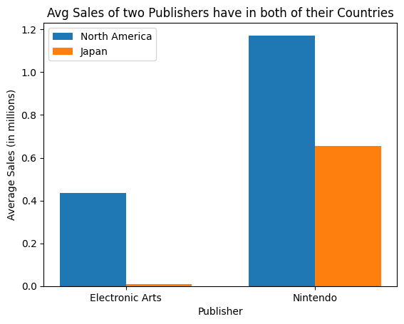

```python
# Isolate a dataframe with just the publishers we want
publishers = ['Electronic Arts', 'Nintendo']
publisher_df = df.loc[df['Publisher'].isin(publishers)]

# Calculate the average sales for each region for each publisher
na_sales = publisher_df.groupby('Publisher')['NA_Sales'].mean()
jp_sales = publisher_df.groupby('Publisher')['JP_Sales'].mean()

# Create an array for the x-axis positions for our two publishers
x = np.arange(len(publishers))

# Create the figure and axes
fig, ax = plt.subplots()

# Bars for NA_Sales
bar1 = ax.bar(x - 0.175, na_sales, width = 0.35, label='North America')

# Bars for JP_Sales
bars2 = ax.bar(x + 0.175, jp_sales, width = 0.35, label='Japan')

# labels
plt.xlabel("Publisher")
plt.ylabel("Average Sales (in millions)")
plt.title("Avg Sales of two Publishers have in both of their Countries")
ax.set_xticks(x)
ax.set_xticklabels(publishers)
plt.legend()

plt.show()
```

In order to see who has the highest popularity in the two countries, we took the average of each company's sales in both the U.S. and Japan, as then the number of games won't affect the sales (since more games will result in more sales overall, which isn't what we're looking for — it's popularity).

As we can see in the graph above, Electronic Arts is less popular in the U.S. (with an average of around 0.43 million per game) than Nintendo is in Japan (with an average of around 0.65 million per game). This could be because of how advertised it is over there, going so far as to create a Super Nintendo World in March of 2021, despite the population of the U.S. being so much higher when this dataset was created (325.1 million in 2017) compared to Japan's population (127 million).

Additionally, we can see how Nintendo's sales in the U.S. are much higher than Japan's, and this is likely due to the population differences we've mentioned earlier. There's also the fact that arcade gaming is more popular in Japan compared to the U.S., which may result in fewer games being purchased. On the other hand, it's interesting to see how little EA is selling in Japan. After organizing the dataset and solely looking at EA games, many titles have 0 recorded Japan sales, with many more in the hundreths of a million. This makes sense considering EA's Japanese office shut down in 2019 after mass layoffs since they wanted to start "ramping down [their] current presence in Japan and Russia," quoted by EA in an article by Game Developer (https://www.gamedeveloper.com/business/ea-closes-japan-and-russia-offices-amid-mass-layoffs).

#### Question 2

Do events like the Olympics affect Sports games Sales?

- Further analysis: How are FIFA (a soccer/football franchise) sales associated with the World Cup for both North America and Europe?

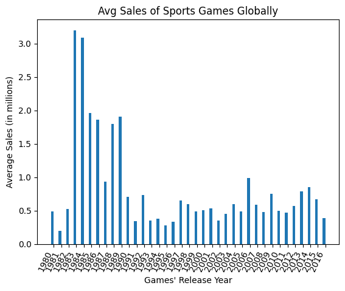

[figure not shown]

```python
# 1) Display the Averages of sports games sales per year

# Isolate a dataframe with just Sports games
sports_genre = ['Sports']
sports_df = df.loc[df['Genre'].isin(sports_genre)]

# Calculate the average sales for each region for each year
sports_mean = sports_df.groupby('Year')['Global_Sales'].mean()

# Create an array for the x-axis positions for our years of FIFA
x = sports_df['Year'].unique().astype(np.int64) #takes the unique years and turns them into ints
x = np.sort(x)

# Create the figure and axes
fig, ax = plt.subplots()

# Bars for sports sales
bars = ax.bar(x - 0.175, sports_mean, width = 0.35)

# labels
plt.xlabel("Games' Release Year")
plt.ylabel("Average Sales (in millions)")
plt.title("Avg Sales of Sports Games Globally")
ax.set_xticks(x)
ax.set_xticklabels(x)
plt.xticks(rotation=65, ha='right')

plt.show()


# 2) Isolate FIFA games into its own dataframe, then display a side-by-side bar graph with the x-axis
# as years and the bars showing both NA_Sales and EU_Sales

# Isolate a dataframe with all games containing "FIFA"
fifa_df = df.loc[df['Name'].str.contains('FIFA')]

# Calculate the average sales for each region for each year
na_sales = fifa_df.groupby('Year')['NA_Sales'].mean()
eu_sales = fifa_df.groupby('Year')['EU_Sales'].mean()

# Create an array for the x-axis positions for our years of FIFA
x = fifa_df['Year'].unique().astype(np.int64) #takes the unique years and turns them into ints
x = np.sort(x)

# Create the figure and axes
fig, ax = plt.subplots()

# Bars for NA_Sales
bars1 = ax.bar(x - 0.175, na_sales, width = 0.35, label='North America')

# Bars for EU_Sales
bars2 = ax.bar(x + 0.175, eu_sales, width = 0.35, label='Europe')

# labels
plt.xlabel("Games' Release Year")
plt.ylabel("Average Sales (in millions)")
plt.title("Sales of FIFA Games in North America and Europe")
ax.set_xticks(x)
ax.set_xticklabels(x)
plt.xticks(rotation=45, ha='right')

plt.legend()

plt.show()
```

Much like before in question 1, we took the average sales of sports and FIFA games per year, as then the number of games published will not interfere with how popular they are. A high number of games in one year where people are less interested might give a higher total global sales than one game in another year where interest is very high.

FIFA Games: Something important to note about FIFA games and their releases, they are released the year before the dates of their games, like FIFA 2016 would come out in 2015. Additionally, FIFA 2000 was also released in 1998 for some reason, yet the amount of sales within that period is still significant as FIFA 2000’s European sales are what raises the graph for the year.

We initially believed that the sales of FIFA games in particular would increase during the World Cup, when the people’s game truly shines and the passion of fans can be fully enjoyed on its virtual counterpart. This might especially be the case for Americans who follow less closely, yet still get the urge to have interest following an especially exciting tournament. This was not the case, as there seemingly is no correlation between World Cup years and not, a quite surprising metric. There is a special mode in FIFA about the World Cup, so an increase in sales makes additional sense, yet to no help in trending sales. The real standout year, in general, was FIFA 2016 (2015), yet there was no World Cup that year, and the impact on the Euros and Copa America (two tournaments in respective continents) wouldn’t have such an impact.

#### Question 3

How were Video Game sales in the United States affected by events such as the 2008 Stock Market Crash? What about September 11, 2001? What other events could explain the rise and fall of video game sales?

- Additional Analyses: How did console releases affect sales? What about when two consoles release at the same time, did global sales increase? Did it lead to less sales over the years after?

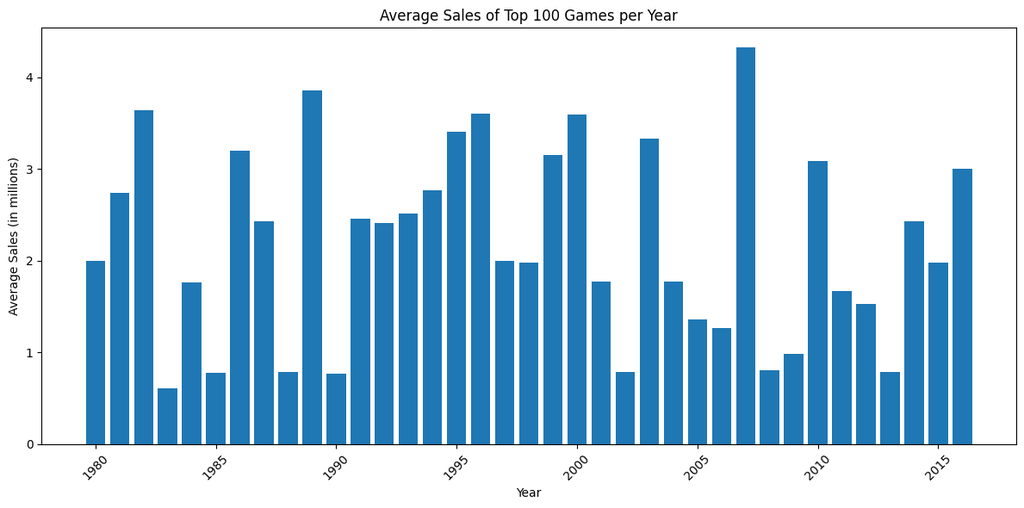

```python
#Instead of just displaying the years again, display the Averages per year so the amount of games won't interfere

#Find the average sales of the top 100 games sold each year
df = df[df["Year"] < 2017]
perYearSales = df.groupby('Year', group_keys=False).apply(pd.DataFrame.nlargest, n=100, columns='Global_Sales').groupby('Year')['Global_Sales'].mean()
X = df["Year"].unique()

# Create an array for the x-axis positions for our years
plt.figure(figsize=(12, 6))
plt.bar(X, perYearSales)
plt.xlabel('Year')
plt.ylabel('Average Sales (in millions)')
plt.title('Average Sales of Top 100 Games per Year')
plt.xticks(rotation=45)

# Display the plot
plt.tight_layout()
plt.show()
```

There is a lot to be determined from this simple display of data, with the ability to create a video game timeline that correlates with the technological and economic advances possible. The reason averages per year for the top 100 games each year were picked as the data to represent this timeline is because having sums of all of the games each year and averaging that would put the data more slanted against more recent games where games are generally more accessible to make. Global sales for each year in general would not work for the same reason, as with more games there is likely to be more sales overall and we want to measure more of the general population's trends on this topic rather than the more indie side.

The early 1980s were a time when household computers were finally being established and the video game industry was but a child. Around this time, the technology industry in the US was competing with Russia to be the first on the moon which led to many other advancements in adjacent fields, like video games. This growth was followed by the console crash of 1983 where terrible games were released quickly in what seemed to be a profitable market for the Atari. This is directly correlated to the economic recession in 1983, where people were so focused on making money that producers were rushed and people generally had less money to spend. In late 1985, the NES was released which had some all-time classic games, leading to a reconnaissance in 1986. The industry generally fluctuated as new consoles were released until a somewhat steady playing field of competition between SONY, Xbox, and Nintendo consoles. The next couple of years were less eventful than the 80s for the gaming industry and overall, represented by fairly steady sales with a slight drop off between 1997 - 1998 being due to transitions between consoles. Post 2000 becomes more eventful with 9/11 coming fairly early to throw a wrench into global politics. The economic impacts of this awful event led to a fear of buying from foreign producers, which were the primary game producers via Nintendo and Sony, leading to a significant fall in sales in 2002. That was abruptly shifted by the release of many cult classics in 2003, like Halo 2 and Call of Duty (a great release time following the political tension) which shifted views towards the escapism of video games. The economic recession of 2008 can also be seen quite visibly in the chart, with 2007 being a standout year for gaming following the release of the global phenomenon that is the Wii in late 2006. After this massive wave of purchases and less purchasing power in total, sales plummeted as people were unable to spend on luxuries.

With the release of consoles, the influx of purchases mostly came in the year following their release and with increased certainty when other consoles were released in competition with each other. For instance, if we look at the stand-out year, 2007, the Xbox 360, PlayStation 2, and Wii were all released in a short timeframe. The sales for games were expected to skyrocket in general as everyone was getting the big games for their console's respective release. This isn't a one-time relation either, with the spike in sales in 2014 being indicative of the release of both the Xbox One and PS4 with an influx of gamers getting one of the two.

## Reflection

Overall, we believe the quality of our report is quite high, with descriptions that are easy to follow and comprehend, useful information that could benefit game developers, and a polished and well-formatted structure, with headings allowing for effective organization.

The visualization models we chose were good for the questions we asked. Since our three insightful questions were about analyzing categorical data (publishers, sports games, and years), bar charts were the most suitable option, and side-by-side bar charts were utilized when we had more than one category and needed to compare.

The main source we consistently used was simply our dataset, and we’ve discussed its accuracy during our report. Another source was an article “EA closes Japan and Russia offices amid mass layoffs” by Alissa McAloon with Game Developer, and this was only used once to help explain why EA wasn’t as popular in Japan despite its popularity elsewhere in the world.

## Download as HTML

```python
### THIS IS TO TURN NOTEBOOK INTO HTML FORMAT AND DOWNLOAD:

from google.colab import files
uploaded_files = files.upload()

# Convert ipynb to html
import subprocess
notebook_filename = list(uploaded_files.keys())[0]
subprocess.run(["pip", "install", "nbconvert"])
subprocess.run(["jupyter", "nbconvert", notebook_filename, "--to", "html"])

# Download the html version
html_filename = notebook_filename[:-6] + ".html" # correct the slicing to avoid error
files.download(html_filename)
```

Upload widget is only available when the cell has been executed in the current browser session. Please rerun this cell to enable.

```
Saving Video_Game_EDA.ipynb to Video_Game_EDA (1).ipynb
```